# Analyzing the Star Lifecycle using the Hertzsprung Russell Diagram

Abby Stokes

2024-11-24

# Introduction

There are many different types of stars, including dwarfs, main sequence (like our sun) and giants, each of which represent a star at a different stage in its lifecycle. Stars with low starting mass are more likely to develop into dwarf stars, whereas highly massive stars are more likely to evolve into a super or hyper giant.

[figure not shown]

# HR Diagram

The Hertzprung-Russell diagram shows the relationship between star absolute magnitude and temperature.

[figure not shown]

# Dataset

The Star Dataset used for this analysis comes from [Kaggle](https://www.kaggle.com/datasets/deepu1109/star-dataset), and includes information on 240 different stars, evenly distributed across 6 different star types (40 each). Star types are as follows:

- Brown Dwarf
- Red Dwarf
- White Dwarf
- Main Sequence
- Supergiant
- Hypergiant

# Dataset

Each observation contains 7 star attributes including

- Absolute Temperature (in K)
- Relative Luminosity (L/Lo)
- Relative Radius (R/Ro)
- Absolute Magnitude (Mv)
- Star Color
- Spectral Class (O,B,A,F,G,K,M)
- Star Type (Red Dwarf, Brown Dwarf, White Dwarf, Main Sequence , SuperGiants, HyperGiants)

# Table 1

Research Question: How do the average values for our numerical variables vary across star types?

Summary of Star Dataset

[output not shown]

# Data Viz 1

Research Question: How does the size of a star vary across star types?

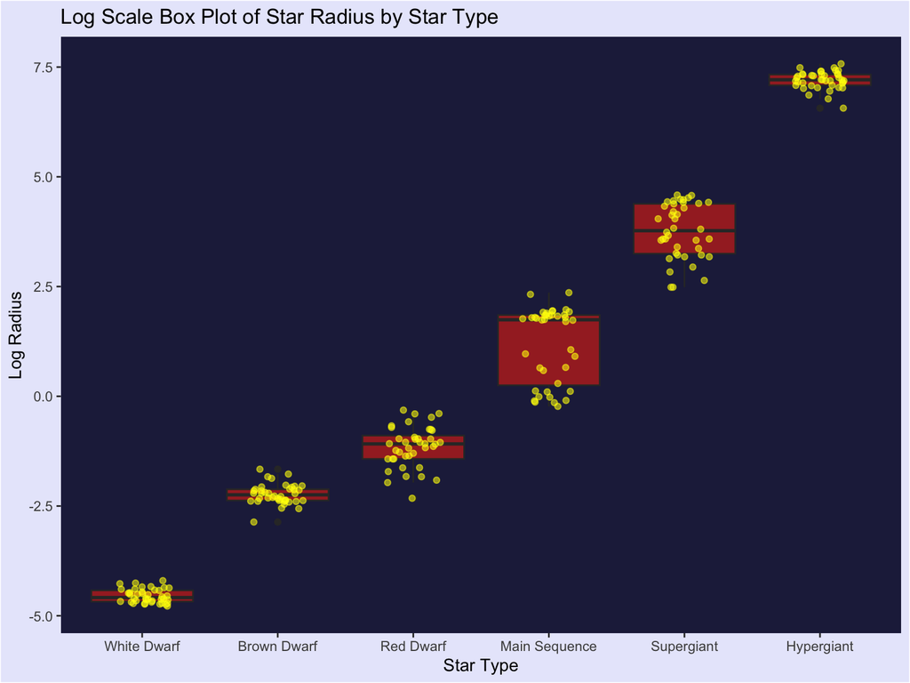

# Data Viz 1

The size of each star type increases **exponentially** with type, making it hard to see smaller stars’ distributions.

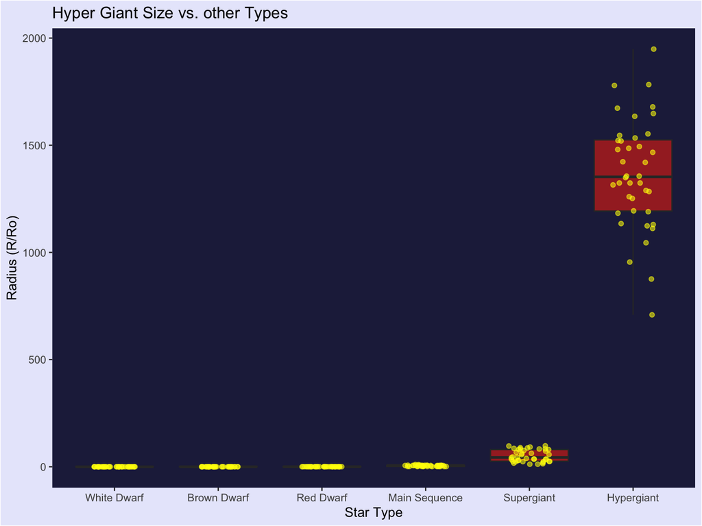

# Data Viz 2

Research Question: How does the temperature of a star vary across star types?

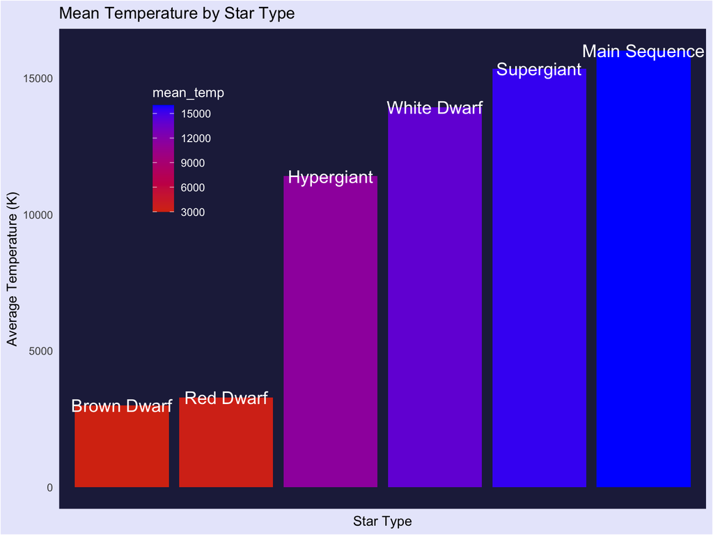

# Data Viz 3

Research Question: What is the relationship between star brightness, temperature, and type (HR Diagram)?

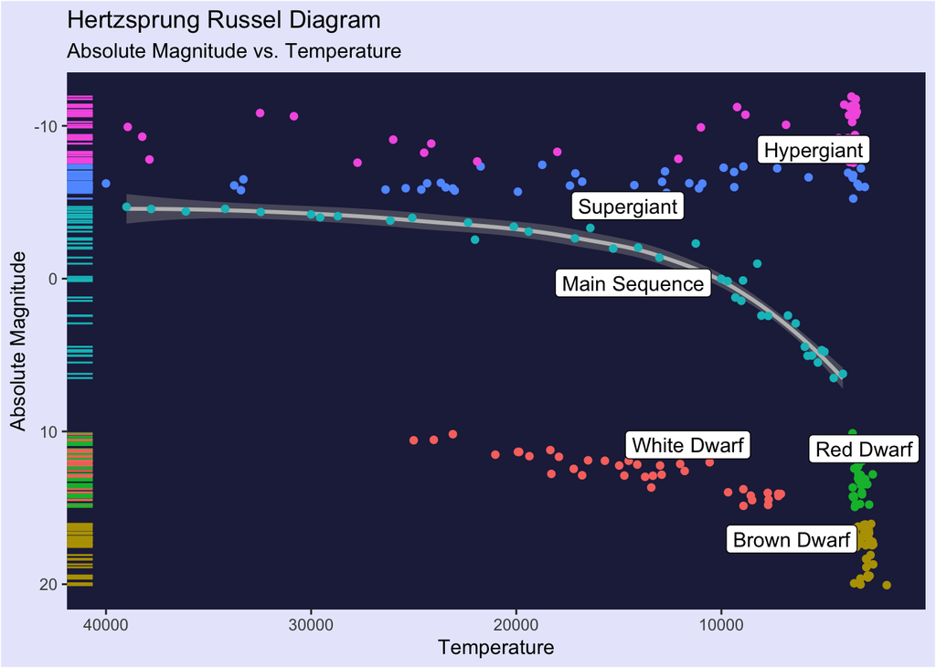

# Conclusions and Future Work

Future Work:

- Build a classification model to predict star type based on attributes such as color, temperature, absolute magnitude, etc.

Conclusion:

- Our dataset very closely followed the patterns as expected by the HR diagram and star life cycle theory.
- HR diagram is a very effective way to portray many different aspects of a given star in just one chart!

# Bonus Data Viz!

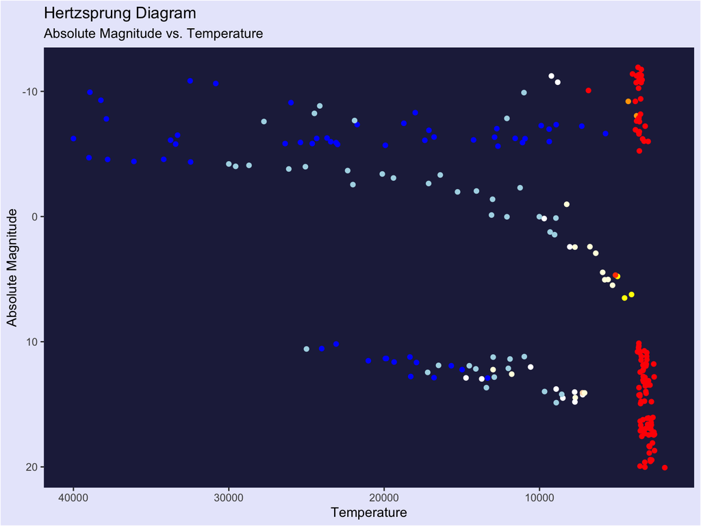

# References